# Ikas-estiloak eta motibazioak hiru fakultatetan

Juan Abasolo

2019-04-04

Dokumentu honek ematen ditu galdetegi bitako erantzunen berri zenbait aldagairen arabera. Txostena sortzeko kodea ere barruan du, egokitu edo berriro egin behar balitz.

## Lagina

Galdetegi biak jende bertsuak erantzun baditu ere, lagina ez da ber-bera galdetegi bietan.

```r
df.chaea <-  read.csv('data/raw/CHAEA/gordinik-CHAEA-zuritutaV2.csv')

# 'ordurako' funtzinoa, denpora-datuak denpora informazinotzat hartzeko
ordurako <- function(x)strptime(x, format = '%Y/%m/%e %k:%M:%S')
# funtzino hori erabili
df.chaea$Marca.temporal <- ordurako(df.chaea$Marca.temporal)
estiloak <- c('ekintzailea', 'hausnarkorra', 'teorikoa', 'pragmatikoa')
```

### Laginaren deskribatzaileak

Denera hiru fakultateetako 164 ikaslek bete dut CHAEA galdetegia

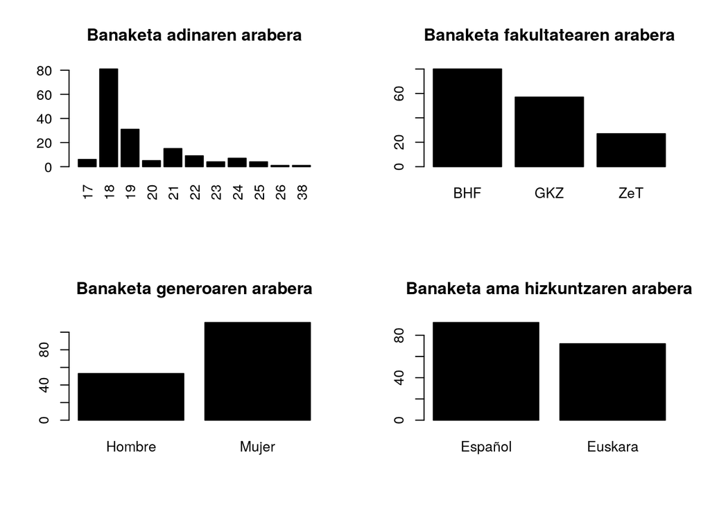

```r
par(mfrow = c(2,2))
barplot(table(df.chaea$Edad), col = 1,
        main = 'Banaketa adinaren arabera', las = 2)
barplot(table(df.chaea$Faku), col = 1,
        main = 'Banaketa fakultatearen arabera')
barplot(table(df.chaea$Género), col = 1,
        main = 'Banaketa generoaren arabera')
barplot(table(df.chaea$Lengua.materna), col = 1,
        main = 'Banaketa ama hizkuntzaren arabera')
```

```r
par(mfrow = c(1,1))
```

### Laginaren deskripzinoaren inguruko beste zeozertzuk

Ez dot uste interesaten jakunik holako datuak azaltzea, baina datuak badaukaguzanez, aztertu dagiguzan:

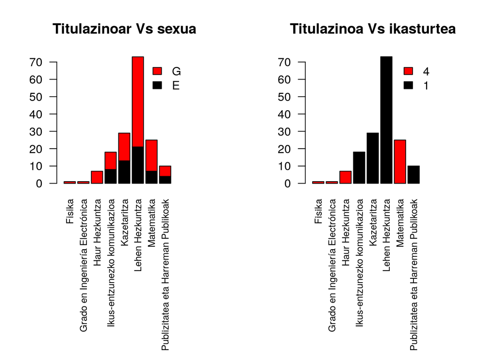

```r
parmarzar <- par('mar')
par(mfrow = c(1,2),
    mar=c(12,4,4,4))
y <- table(df.chaea$Género, df.chaea$Nombre.de.la.titulación)
barplot(y,
        col=1:nrow(y),
        xlim=c(0, ncol(y) + 3),
        main = 'Titulazinoar Vs sexua',
        las = 2, cex.names = 0.8,
        legend.text=c('E','G'),
    args.legend=list(
      x=ncol(y) + 3,
      y=max(colSums(y)),
      bty = "n"
    ))
y <- table(df.chaea$Curso, df.chaea$Nombre.de.la.titulación)
barplot(y,
        col=1:nrow(y),
        xlim=c(0, ncol(y) + 3),
        main = 'Titulazinoa Vs ikasturtea', las = 2, cex.names = 0.8,
       legend.text=TRUE,
    args.legend=list(
      x=ncol(y) + 3,
      y=max(colSums(y)),
      bty = "n"))
```

```r
par(mfrow = c(1,1),
    mar = parmarzar)
```

Irudi bietan ikusten danez, oso presentzia gutxi dute karrera batzuk; ganera, lehenengoan ikusten danez laginean bazterrekoak liratekeen karreretan ez dago informatzaile gizonezkorik (fisika, electrónica eta haur hezkuntzan), eta ikasturteari jagokonez, banaketa orekaturik ez dago.

Ikasturtearen eta, akaso, adinaren araberako analisirik ez litzateke egin beharko. Karreraren araberakorik be ez dau emoten egin behar litzatekeenik.

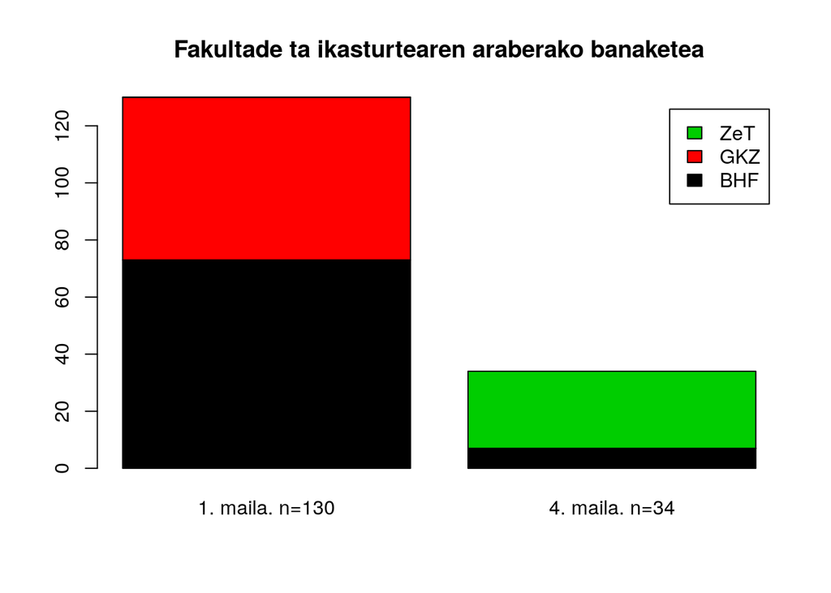

```r
barplot(table(df.chaea$Faku,df.chaea$Curso), col = 1:3,
        names.arg = paste(levels(factor(df.chaea$Curso)), table(df.chaea$Curso), sep = '. maila. n='),
        legend.text = levels(df.chaea$Faku),
        main = 'Fakultade ta ikasturtearen araberako banaketea')
```

Azken horretako datuotan oinarrituta, emoten dau bideragarria izan litekeala, soilik fakultate bi hartuta, lehenengo mailaren araberako analisiea egitea.

Jakina, azkan hori egingo bagendu ez geunke sartuko Zientzia eta Teknologiako emoitzik sartuko alderaketan, eta letrak/zientziak alderaketa egitea interesgarria izaten da.

Bestalde, ZeTeko 4. mailako datuak sartuko bagenduz, zientzietakoek 4. mailarako garatuta daukezan ikas estrategiak alderatuko geunkez magiseko ikasleak batxilergotik etorri barritan daukezanakin (bazterrekoak dira, eta BHFko HHko 4. mailakoak beste kopuruen aldean).

**Zein interes dogun zer esateko, aztertu behar dogu zeintxuk datu zelan erabili.**

Segidako analisi guztiak datu guztiakin batera eginda dagoz, baina ez litzateke gaitzegia, goiko erizpideak kontuan eukita, beste eraren bateko analisia be egitea.

## CHAEA

```r
# Datuak antolatu interpretatzeko
# Erantzunak baloratzeko datuak sartu -----------------------
neurriak.hartzekoa <- t(read.csv('data/raw/CHAEA/ITEMak_antolau.csv'))
# neurriak.hartzekoa

# Zenbatu denak --------------------------
for(i in 1:length(row.names(df.chaea))){
  # print(i)
  df.chaea$ACTIVO[i] <- sum(df.chaea[i,7:86]+neurriak.hartzekoa[2,] == 2)
  df.chaea$REFLEXIVO[i] <- sum(df.chaea[i,7:86]+neurriak.hartzekoa[3,] == 2)
  df.chaea$TEORICO[i] <- sum(df.chaea[i,7:86]+neurriak.hartzekoa[4,] == 2)
  df.chaea$PRAGMATICO[i] <- sum(df.chaea[i,7:86]+neurriak.hartzekoa[5,] == 2)
}

# Identifikau nagusia
# df.chaea$nagusi <-
for(i in 1:length(row.names(df.chaea))){
  # print(i)
  m <- max(df.chaea[i,89:92])
  df.chaea$nagusi[i] <- ifelse(m==df.chaea[i,89], 'ACTIVO',
                           ifelse(m==df.chaea[1,90], 'REFLEXIVO',
                                  ifelse(m==df.chaea[1,91], 'TEORICO', 'PRAGMATICO')))
}
```

Ikasketa estiloen gaineko galdetegiak, 80 itemen balorazioaren bitartez, inkestatuaren ikasestiloen garapenen berri ematen du lautan banatuta:

- Activo, *ekintzailea*
- Pragmático, *pragmatikoa*
- Reflexivo, *hausnarkorra*
- Teorico, *teorikoa*

Banaketa horren oinarri teorikoa Kolb-ek ezarri zuen (1984). Honey eta Mumford (1986) bikoteak *Learning Styles Questionnaire* (LSQ) eraiki zuen eta Alonso, Gallego & Honeyk (1996) gaztelaniazko egokitzapena aurkeztu zuten.

Galdetegiko erantzunak, beraz, dimentsio aniztunak dira. Baliteke erantzunak ematen dituen delako batek hiru dimentsio oso garatuta dituela erakustea eta besteren bat agertzea ez duena bat bera ere ondo garatuta. Jakina, hala izatea baliteke ere, datuek zer erakusten duten ikusi behar da.

Galdetegi hau interpretatzeko orduan, Alonsok-eta proposatzen dute baremo orokor bat, zeinetan balidazio prozesuan lortutako datuen arabera aztertu duten erantzun kopuruaren banaketa eta banaketa horren arabera ikas-estilo bakoitzari neurri bat esleitzen dioten, informatzaileak zer lehenesten duen: *lehenespen oso baxua*, *baxua*, *neurritsua*, *altua* eta *oso altua*.

Segidan, transformazio kualitatiborik gabeko datuen errepresentazio grafikoa

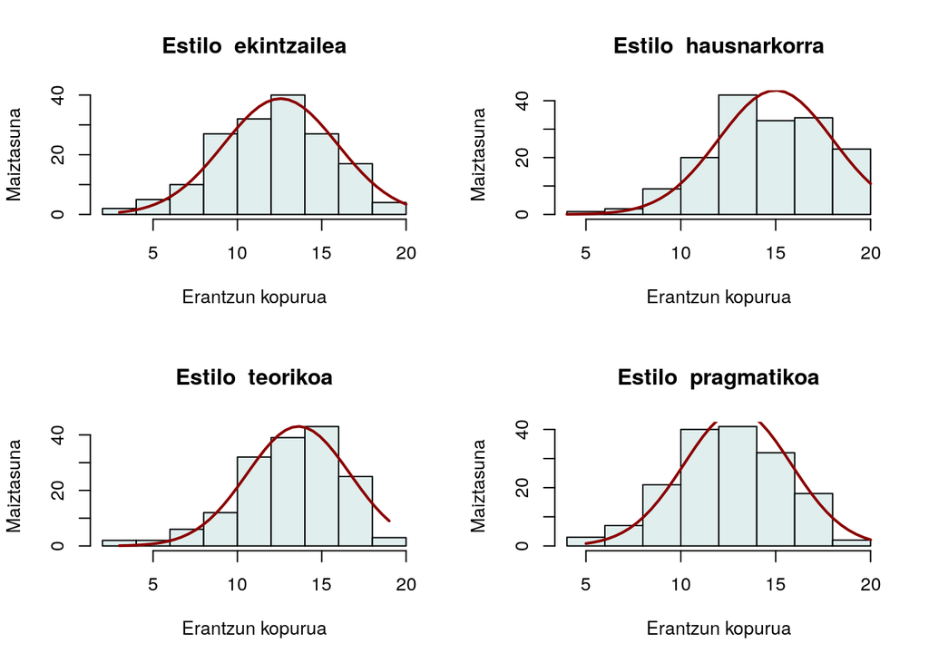

```r
aldagaia <- df.chaea$ACTIVO
zer <- 'prl'

plot.htad <- function(aldagaia, zer){
  x <- aldagaia
  h <- hist(x, breaks=10,
            col="azure2",
            main= paste('Estilo ', zer),
            # sub = paste('W = ', round(y$statistic,3), 'p-balioa', round(y$p.value, 3)),
            ylab = 'Maiztasuna',
            xlab = 'Erantzun kopurua')
  xfit<-seq(min(x),max(x),length=40)
  yfit<-dnorm(xfit,mean=mean(x),sd=sd(x))
  yfit <- yfit*diff(h$mids[1:2])*length(x)
  # plot(h)
  lines(xfit, yfit, col = "darkred", lwd = 2)
}
par(mfrow = c(2,2))
plot.htad(df.chaea$ACTIVO, 'ekintzailea')
plot.htad(df.chaea$REFLEXIVO, 'hausnarkorra')
plot.htad(df.chaea$TEORICO, 'teorikoa')
plot.htad(df.chaea$PRAGMATICO, 'pragmatikoa')
```

```r
par(mfrow = c(1,1))
```

#### Kontuan euki behar doguzanak

Guk batutako erantzunak ez jagokoz banaketa normalari. Ez dakigu, baina, zelakuk ixan zirian Alonsok-eta batutakoak. Eurek egin eben banaketa eta teoriaren arabera, begitantzen jat eurona be ez zala banatuko kurba normalaren arabera.

*Normalize* teknikak erabili geinkez, baina batetik lortzen dana, bestetik galtzen da; normaltasuna neurtzeko test bat erabilita aztertzen da segidan: Kolmogorov-Smirnov-ena. Normaltasuna erakutsi baino, banaketa normala ez dala erakustea dauka helburu testak; beraz, gure interesa da H<sub>0</sub> ez baztertzea, p-balio altuakin:

```r
aztertu <- df.chaea$PRAGMATICO
y1 <- ks.test(aztertu, pnorm, mean(aztertu), sd(aztertu))
```

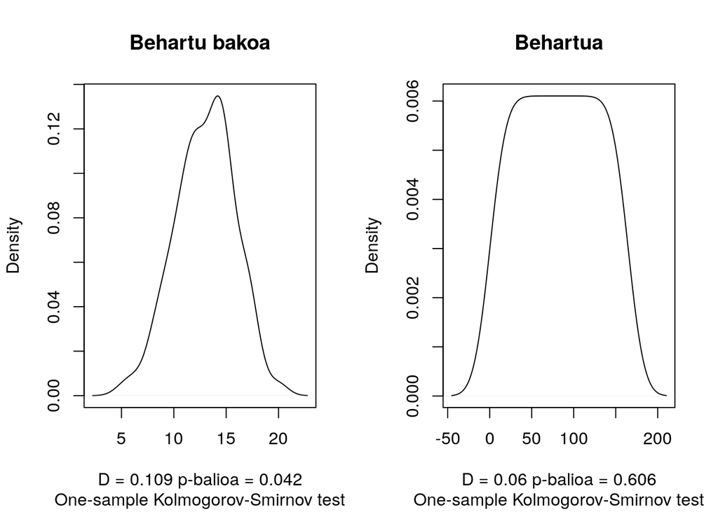

```r
aztertu2 <- rank(aztertu, ties.method = 'random')
y2 <- ks.test(aztertu2, pnorm, mean(aztertu2), sd(aztertu2))

par(mfrow = c(1,2))
plot(density(aztertu),
     main = "Behartu bakoa",
     sub = y1$method,
     xlab = paste('D =', round(y1$statistic, 3), 'p-balioa =', round(y1$p.value, 3)))
plot(density(aztertu2),
     main = 'Behartua',
     sub = y2$method,
     xlab = paste('D =', round(y2$statistic, 3), 'p-balioa =', round(y2$p.value, 3)))
```

```r
par(mfrow = c(1,1))
```

Beraz, kasu honetan test batek dinosku banaketa ez dala normala (besteak ez dino hori, baina batek esanda nahikoa dogu baztertzeko). Bigarrenaren kasuan, zenbakiz normaltasuna ez baztertzea lortu badogu be, nabarmena da kurtosisean izango lituzkeen arazoak.

```r
# Kurba normalaren kurtosisa:
x <- rnorm(100)
e1071::kurtosis(x)
```

```
## [1] 0.01254445
```

```r
# Behartu gabeko datuena:
e1071::kurtosis(aztertu)
```

```
## [1] -0.188313
```

```r
# Behartutakoena
e1071::kurtosis(aztertu2)
```

```
## [1] -1.221972
```

Beraz, zoroarena egin badeikegu be, badakigu normalizatzeak gezurra lekarkeana eta JCR-etatik urrunduko gaituana, estatistikari lupaz begiratu ezkero, behintzat.

### Datuak interpretatzeko baremo orokorra

|  | 10% | 20% | 40% | 20% | 10% |
| --- | --- | --- | --- | --- | --- |
|  | Preferencia |  |  |  |  |
|  | Muy Baja | Baja | Moderada | Alta | Muy alta |
| Activo | 0-6 | 7-8 | 9-12 | 13-14 | 15-20 |
| Reflexivo | 0-10 | 11-13 | 14-17 | 18-19 | 20 |
| Teórico | 0-6 | 7-9 | 10-13 | 14-15 | 16-20 |
| Pragmático | 0-8 | 9-10 | 11-13 | 14-15 | 16-20 |

orr. 114

```r
# Activo
activo.q <- vector()
activo.q[df.chaea$ACTIVO < 7] <- 1
activo.q[df.chaea$ACTIVO >= 7 & df.chaea$ACTIVO < 9] <- 2
activo.q[df.chaea$ACTIVO >= 9 & df.chaea$ACTIVO < 13] <- 3
activo.q[df.chaea$ACTIVO >= 13 & df.chaea$ACTIVO < 15] <- 4
activo.q[df.chaea$ACTIVO >= 15] <- 5
df.chaea$activo.q <- as.factor(activo.q)

levels(df.chaea$activo.q) <- c("Muy baja", "Baja", "Moderada", "Alta", "Muy alta")

# Reflexivo
reflexivo.q <- vector()
reflexivo.q[df.chaea$REFLEXIVO < 11] <- 1
reflexivo.q[df.chaea$REFLEXIVO >= 11 & df.chaea$REFLEXIVO < 14] <- 2
reflexivo.q[df.chaea$REFLEXIVO >= 14 & df.chaea$REFLEXIVO < 18] <- 3
reflexivo.q[df.chaea$REFLEXIVO >= 18 & df.chaea$REFLEXIVO < 20] <- 4
reflexivo.q[df.chaea$REFLEXIVO >= 20] <- 5
df.chaea$reflexivo.q <- as.factor(reflexivo.q)

levels(df.chaea$reflexivo.q) <- c("Muy baja", "Baja", "Moderada", "Alta", "Muy alta")

# Téorico
teorico.q <- vector()
teorico.q[df.chaea$TEORICO < 7] <- 1
teorico.q[df.chaea$TEORICO >= 7 & df.chaea$TEORICO < 10] <- 2
teorico.q[df.chaea$TEORICO >= 10 & df.chaea$TEORICO < 14] <- 3
teorico.q[df.chaea$TEORICO >= 14 & df.chaea$TEORICO < 16] <- 4
teorico.q[df.chaea$TEORICO >= 16] <- 5
df.chaea$teorico.q <- as.factor(teorico.q)

levels(df.chaea$teorico.q) <- c("Muy baja", "Baja", "Moderada", "Alta", "Muy alta")

# Pragmático
pragmatico.q <- vector()
pragmatico.q[df.chaea$PRAGMATICO < 9] <- 1
pragmatico.q[df.chaea$PRAGMATICO >= 9 & df.chaea$PRAGMATICO < 11] <- 2
pragmatico.q[df.chaea$PRAGMATICO >= 11 & df.chaea$PRAGMATICO < 14] <- 3
pragmatico.q[df.chaea$PRAGMATICO >= 14 & df.chaea$PRAGMATICO < 16] <- 4
pragmatico.q[df.chaea$PRAGMATICO >= 16] <- 5
df.chaea$pragmatico.q <- as.factor(pragmatico.q)

levels(df.chaea$pragmatico.q) <- c("Muy baja", "Baja", "Moderada", "Alta", "Muy alta")
```

Horren banaketa honela geratzen da, beraz:

```r
knitr::kable(data.frame(rbind(table(df.chaea$activo.q),
                   table(df.chaea$reflexivo.q),
                   table(df.chaea$teorico.q),
                   table(df.chaea$pragmatico.q)
                   ), row.names = estiloak), row.names = T)
```

|  | Muy.baja | Baja | Moderada | Alta | Muy.alta |
| --- | --- | --- | --- | --- | --- |
| ekintzailea | 7 | 10 | 59 | 40 | 48 |
| hausnarkorra | 12 | 41 | 75 | 26 | 10 |
| teorikoa | 4 | 10 | 61 | 39 | 50 |
| pragmatikoa | 10 | 21 | 56 | 50 | 27 |

### Ikas-estiloen garapenaren batez bestekoa

Helburu izan diren 3 fakultateetako ikasleengan ikus dezakegu antzekoa baina desberdinak diren ikas-estiloen garapenak.

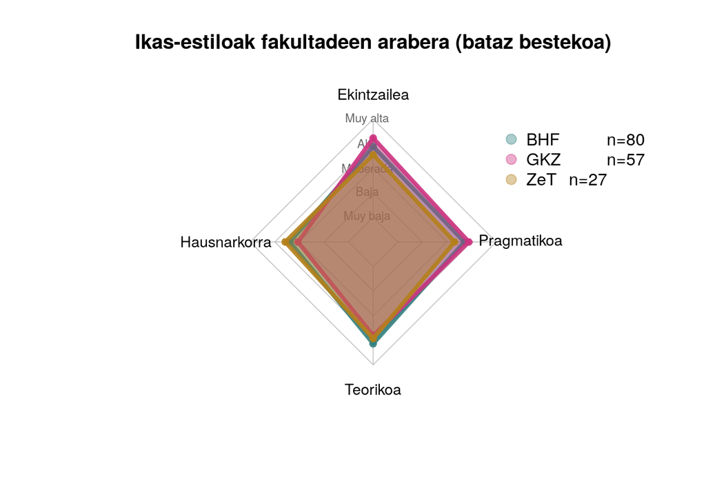

```r
### Ahalegina bost neurritan (ta ez 20 item)

df.chaea$activo.qn <- as.numeric(df.chaea$activo.q)
df.chaea$reflexivo.qn <- as.numeric(df.chaea$reflexivo.q)
df.chaea$teorico.qn <- as.numeric(df.chaea$teorico.q)
df.chaea$pragmatico.qn <- as.numeric(df.chaea$pragmatico.q)

starrerako <- aggregate(x = df.chaea[, c("activo.qn","reflexivo.qn", "teorico.qn", "pragmatico.qn")],
                        by = list(df.chaea$Faku),
                        FUN = mean)
rownames(starrerako) <- starrerako[,1]

starrerako <- rbind(rep(5,4) , rep(0,4) , starrerako[, 2:length(names(starrerako))])

# fmsb::radarchart(starrerako)

colors_border=c( rgb(0.2,0.5,0.5,0.9), rgb(0.8,0.2,0.5,0.9) , rgb(0.7,0.5,0.1,0.9) )
colors_in=c( rgb(0.2,0.5,0.5,0.4), rgb(0.8,0.2,0.5,0.4) , rgb(0.7,0.5,0.1,0.4) )
fmsb::radarchart( starrerako, axistype=1 ,
                  #custom polygon
                  pcol=colors_border ,
                  pfcol=colors_in ,
                  plwd=4 ,
                  plty=1,
                  #custom the grid
                  cglcol="grey", cglty=1,
                  axislabcol="gray40",
                  caxislabels=levels(df.chaea$activo.q),
                  calcex = 0.7,
                  cglwd=0.8,
                  #custom labels
                  vlcex=0.9,
                  vlabels = c("Ekintzailea","Hausnarkorra","Teorikoa", "Pragmatikoa"),
                  # Izenburua
                  title = 'Ikas-estiloak fakultadeen arabera (bataz bestekoa)'
)

legend(x = 1, y = 1,
       legend = paste(rownames(starrerako[-c(1,2),]), table(df.chaea$Faku), sep = '\t n=' ),
       bty = "n",
       pch=20 ,
       col=colors_in,
       text.col = "black",
       cex=1,
       pt.cex=2)
```

- BHFko ikasleriak estilo teorikoan eman ditu emaitzik gorenak, beste fakultatetakoen aldean.
- GKZko ikasleek estilo ekintzailean eta pragmatikoan eman dute erantzun positibo gehien.
- zeTko ikasleen erantzunetan aurkitu dira, berriz, estilo hausnarkorreko erantzun gehien.

#### Guk kontuan izatekoa:

Hemen be beste gauza bat gabiltzaz behartuten. Batez bestekoak egiten doguz aldagai kualitatibo ordinalakin. Hau da:

- Zenbatu doguz bakotxaren erantzunak estilo bakotxaren arabera.
- Bakotxak estilo bakotxean zein *garapen* maila daukan kalkulau dog (Alonsoren-ta arabera)
- Garapen maila horreei zenbaki bat emon deutsague (muy baja =1, baja=2… muy alta = 5)
- Zenbaki (ordinal) horren bataz bestekoa atara dogu.
- Hori erakusten dogu taldearen ezaugarritzat.

Pentsau lei, datuak ordinalak direanez, media/erdiko balioa erabili behar geunkela. Baina horreek arazo bi daukoz:

1. Ez da alderik ikusten guk erakutsi nahi doguzan elementuen artean (fakultadeak)
2. 100etik goragoko datuakin gabiltzanez, matematikari batzuk onargarri jotzen dabe datu ez parametrikoak parametrikotzat jotzea. Baina hor letra behar dot, leidu-eta, eta ez dakit non.

```r
starrerako <- aggregate(x = df.chaea[, c("activo.qn","reflexivo.qn", "teorico.qn", "pragmatico.qn")],
                        by = list(df.chaea$Faku),
                        FUN = median)
rownames(starrerako) <- starrerako[,1]

starrerako <- rbind(rep(5,4) , rep(0,4) , starrerako[, 2:length(names(starrerako))])

# fmsb::radarchart(starrerako)

colors_border=c( rgb(0.2,0.5,0.5,0.9), rgb(0.8,0.2,0.5,0.9) , rgb(0.7,0.5,0.1,0.9) )
colors_in=c( rgb(0.2,0.5,0.5,0.4), rgb(0.8,0.2,0.5,0.4) , rgb(0.7,0.5,0.1,0.4) )
fmsb::radarchart( starrerako, axistype=1 ,
                  #custom polygon
                  pcol=colors_border ,
                  pfcol=colors_in ,
                  plwd=4 ,
                  plty=1,
                  #custom the grid
                  cglcol="grey", cglty=1,
                  axislabcol="gray40",
                  caxislabels=levels(df.chaea$activo.q),
                  calcex = 0.7,
                  cglwd=0.8,
                  custom labels
                  vlcex=0.9,
                  vlabels = c("Ekintzailea","Hausnarkorra","Teorikoa", "Pragmatikoa"),
                  # Izenburua
                  title = 'Ikas-estiloak fakultadeen arabera (mediana)'
)

# legend(x = 1, y = 1,
#        legend = paste(rownames(starrerako[-c(1,2),]), table(df.chaea$Faku), sep = ' n=' ),
#        bty = "n",
#        pch=20 ,
#        col=colors_in,
#        text.col = "black",
#        cex=1.2,
#        pt.cex=3)
```

[output not shown]

### Estilo nagusiak

Beste ikuskera baten azterketa ere baimentzen du CHAEA galdetegiak, gailentzen diren ikasestiloena. Badakigu, beraz, ikasle gehienek ikas-estilo guztiak neurri ertainean garatuta dituztela. Hala eta guztiz ere, ikasleek estilo batzuk garatuago dituzte beste batzuk baino. Horrela, azter ditzakegu fakultate bakoitzean zein estilo gailentzen diren.

```r
x <- subset(df.chaea, Faku=='ZeT')

# table(x$activo.q, x$teorico.q)
# round(prop.table(table(x$reflexivo.q, x$pragmatico.q))*100, 3)

x <- aggregate(x = df.chaea[, c("activo.qn","reflexivo.qn", "teorico.qn", "pragmatico.qn")],
                        by = list(df.chaea$Faku),
                        FUN = mean)
row.names(x) <- x$Group.1
x <- x[ , 2: length(names(x))]
x <- round(x,2)

x %>%
  mutate(
    x = row.names(.),
    activo.qn = cell_spec(activo.qn, color = ifelse(activo.qn == max(activo.qn), "red", "black")),
    reflexivo.qn = cell_spec(reflexivo.qn, color = ifelse(reflexivo.qn == max(reflexivo.qn), "red", "black")),
    teorico.qn = cell_spec(teorico.qn, color = ifelse(teorico.qn == max(teorico.qn), "red", "black")),
    pragmatico.qn = cell_spec(pragmatico.qn, color = ifelse(pragmatico.qn == max(pragmatico.qn), "red", "black"))
    ) %>%

  select(x, activo.qn, reflexivo.qn, teorico.qn, pragmatico.qn) %>%
  kable(escape = F, col.names = c('Fakultatea', estiloak), caption = 'Ikasestiloak hiru fakultateetan') %>%
  kable_styling("striped", full_width = F) %>%
  footnote(general = "Gorriak gorengo balioa nabarmentzen du ikas-estiloan. ")
```

[output not shown]

#### Banaketaren ikuskera grafikoa

```r
# Analisi grafikoa eta distribuzioa egiteko funtzioa
f.barIE <-function(aldagaia1, aldagaia2, zer1='zozer', zer2='zozetaka'){
  y <- table(aldagaia1, aldagaia2)
  yt <- suppressWarnings(chisq.test(y))
  barplot(y,
          beside = T,
          col=RColorBrewer::brewer.pal(n = nrow(y), name = "RdBu"),
          # biderketak gehitu behar jakoz beside=T emon deutsatelako
          xlim=c(0, ncol(y)*nrow(y) + 3*nrow(y)),
          main = paste('IE', zer1, zer2),
          sub = paste('chi^2',
                      '=',
                      round(yt$statistic,3),
                      'p-balioa =',
                      round(yt$p.value,3)),
          las = 1,
          cex.names = 0.8,
          legend.text=T,
          args.legend=list(
            x=ncol(y)*nrow(y) + 3*nrow(y),
            y=max(y),
            bty = "n"
          )
  )

  vcd::mosaic(vcd::structable(y), shade=TRUE, legend=TRUE)
}
```

```r
f.barIE(df.chaea$Faku, df.chaea$activo.q, 'ekintzailea', 'fakultateka')
```

[output not shown]

```r
f.barIE(df.chaea$Faku, df.chaea$reflexivo.q, 'hausnarkorra', 'fakultateka')
```

[output not shown]

```r
f.barIE(df.chaea$Faku, df.chaea$teorico.q, 'teorikoa', 'fakultateka')
```

[output not shown]

```r
f.barIE(df.chaea$Faku, df.chaea$pragmatico.q, 'ekintzailea', 'fakultateka')
```

[output not shown]

**Aztertzeko**

## EMSI

Asko aurreratzeko oindio

- Laburpena dago
- Ez dot egin proba estatistikorik  
  Begitu zuk, mesedez:
  - Ingelesezko artikuluan ia motibazino eren araberako batuketarik edo egiten dan; ez esateko *lau itemetatik bitan hau eta baten bestea…*
  - Era honetako konparazinoietan erabilten dan ala ez Kruskal-Wallisen aproba. Datuai ondo jagoke, baina ez dakit pedagogian ohiturrarik dagoan. $\chi^2$-k ez dauko kontuan eskala ordinala dala eta ez geunke jarraikakotzat hartu behar. U Mann-Withney-Wilcoxon aprobak ez dosku balio, dikotomikuakin egiten dabelako, ta guk hiru fakultade daukoguz

```r
df.emsi <- read.csv('data/raw/EMSI/gordinik-EMSI-zurituta.csv')

# str(df.emsi)

mintrinseca <- c(1, 5, 9, 13)
mregulacionidentificada <- c(2, 6, 10, 14)
mregulacionexterna <- c(3, 7, 11, 15)
mamotivacion <- c(4, 8, 12, 16)

# Aldagaien izenak egokitu (read.csv-k izen arraroak eragiten ditualako)
df.itemak.emsi <- df.emsi[, 7:22]
emsi.itemak <- read.csv('data/raw/EMSI/gordinik-EMSI-zurituta.csv', header = F, stringsAsFactors = F)[1,7:22]
emsi.itemak <- as.matrix(emsi.itemak)
emsi.itemak <-  as.character(emsi.itemak[1,])
names(df.itemak.emsi) <- emsi.itemak

# Likert objektuak sortu

# Gutztiak
lik.emsi <- likert::likert(df.itemak.emsi)
lik.emsi.faku <- likert::likert(df.itemak.emsi, grouping = df.emsi$Faku)
```

#### Homozedastizitatea: aldeetako adierazgarritasunaz zer ikus daitekeen

Bariantzen homogeneotasuna aztertzeko

```r
e.l <- c()
levene.pbalioak <- c()
for (i in 1:length(names(df.itemak.emsi))){
  e.l <- car::leveneTest(as.numeric(df.itemak.emsi[,i])~df.emsi$Faku, center = 'median')
  levene.pbalioak[i] <- round(e.l$`Pr(>F)`[1], 3)
}

knitr::kable(data.frame(itemak = emsi.itemak,
           p.balioak = levene.pbalioak,
           ebidentziarik = ifelse(levene.pbalioak < 0.05, '\  \ bai', '\ \ ez')),
           row.names = F,
           col.names = c('Itemak', 'p-balioa', ' ?'))
```

Itemak

p-balioa

?

1. Porque creo que esta actividad es interesante.

0.290

ez

2. Porque se supone que debo hacerlo.

0.255

ez

3. Por mi propio bien

0.093

ez

4. Puede que haya buenas razones para realizar esta actividad, pero yo no veo ninguna

0.571

ez

5. Porque disfruto con esta actividad

0.589

ez

6. Porque creo que esta actividad es buena para mí

0.131

ez

7. Porque es algo que tengo que hacer

0.898

ez

8. Realizo esta actividad, pero no estoy seguro de si vale la pena

0.386

ez

9. Porque esta actividad es divertida

0.083

ez

10. Por decisión personal

0.880

ez

11. Porque no tengo otra alternativa

0.487

ez

12. No lo sé. No veo qué me aporta esta actividad

0.523

ez

13. Porque me siento bien realizando esta actividad

0.130

ez

14. Porque creo que esta actividad es importante para mí

0.339

ez

15. Porque creo que tengo que hacerlo

0.363

ez

16. Hago esta actividad, pero no estoy seguro de que sea conveniente continuar con ella

0.242

ez

Beraz, Leveneren testak erakusten digunez, homogeneotasunik ez dagoela esateko ebidentziarik ez dugu. Horrek baimentzen digu itemen analisirako Kruskal-Wallisen testa erabiltzea, alde adierazgarriak aurkitu nahirik.

Kruskal-Wallisen testak $\chi^2$a kalkulatzen du aldagai ordinalekin, hau da, hurrenkeraren garrantzia ere kontuan du, banaketan alde adierazgarririk dagoenentz esateko orduan.

```r
e.k.ch <- c()
e.k.pb <- c()
for (i in 1:length(names(df.itemak.emsi))){
  e.k <- kruskal.test(df.itemak.emsi[,i]~df.emsi$Faku)
  e.k.ch[i] <- e.k$statistic
  e.k.pb[i] <- e.k$p.value
}

df.k <- data.frame(itema = emsi.itemak,
           "$\\chi^2$" = round(e.k.ch, 3),
           'p-balioa' = round(e.k.pb, 3),
           ' ' = ifelse(e.k.pb > 0.05, '',
                                   ifelse(e.k.pb > 0.01, '*',
                                          ifelse(e.k.pb > 0.001, '**', '***'
                                          ))))

knitr::kable(df.k, col.names = c('Itema', '$\\chi^2$', 'p-balioa', ''))
```

Itema

$\chi^2$

p-balioa

1. Porque creo que esta actividad es interesante.

5.601

0.061

2. Porque se supone que debo hacerlo.

1.276

0.528

3. Por mi propio bien

3.869

0.144

4. Puede que haya buenas razones para realizar esta actividad, pero yo no veo ninguna

3.670

0.160

5. Porque disfruto con esta actividad

9.943

0.007

6. Porque creo que esta actividad es buena para mí

4.682

0.096

7. Porque es algo que tengo que hacer

0.407

0.816

8. Realizo esta actividad, pero no estoy seguro de si vale la pena

0.313

0.855

9. Porque esta actividad es divertida

11.738

0.003

10. Por decisión personal

3.080

0.214

11. Porque no tengo otra alternativa

2.320

0.313

12. No lo sé. No veo qué me aporta esta actividad

3.023

0.221

13. Porque me siento bien realizando esta actividad

1.426

0.490

14. Porque creo que esta actividad es importante para mí

10.385

0.006

15. Porque creo que tengo que hacerlo

5.139

0.077

16. Hago esta actividad, pero no estoy seguro de que sea conveniente continuar con ella

0.157

0.925

EMSI galdetegiak motibazioaren inguruko lau dimentsio neurtzen ditu; aldea euretariko bitan aurkitu da: *Motivación intrínseca* eta *regulación identificada*n.

```r
e.p.w.t <- suppressWarnings(pairwise.wilcox.test(x = as.numeric(df.itemak.emsi[, 5]),
                                g = df.emsi$Faku, p.adjust.method = "holm"))
knitr::kable(round(e.p.w.t$p.value, 3), caption = paste(emsi.itemak[5], 'itemean aldearen p.balioa'))
```

Porque disfruto con esta actividad itemean aldearen p.balioa

|  | BHF | GKZ |
| --- | --- | --- |
| GKZ | 0.083 | NA |
| ZeT | 0.083 | 0.009 |

Beraz, alde adierazgarria aurkitu dugu soilik ZeT eta GKZ fakultateen artean

```r
e.p.w.t <- suppressWarnings(pairwise.wilcox.test(x = as.numeric(df.itemak.emsi[, 9]),
                                g = df.emsi$Faku, p.adjust.method = "holm"))
knitr::kable(round(e.p.w.t$p.value, 3), caption = paste(emsi.itemak[9], 'itemean aldearen p.balioa'))
```

Porque esta actividad es divertida itemean aldearen p.balioa

|  | BHF | GKZ |
| --- | --- | --- |
| GKZ | 0.003 | NA |
| ZeT | 0.825 | 0.032 |

Item honetan alde adierazgarria aurkitu da GKZ eta beste bien artean.

```r
e.p.w.t <- suppressWarnings(pairwise.wilcox.test(x = as.numeric(df.itemak.emsi[, 14]),
                                g = df.emsi$Faku, p.adjust.method = "holm"))
knitr::kable(round(e.p.w.t$p.value, 3), caption = paste(emsi.itemak[14], 'itemean aldearen p.balioa'))
```

Porque creo que esta actividad es importante para mí itemean aldearen p.balioa

|  | BHF | GKZ |
| --- | --- | --- |
| GKZ | 0.358 | NA |
| ZeT | 0.004 | 0.057 |

Azkenik, 14. itemean alde adierazgarria ZeT eta BHF fakultateko ikasleen artean aurkitu da.

### Motivación intrinseca

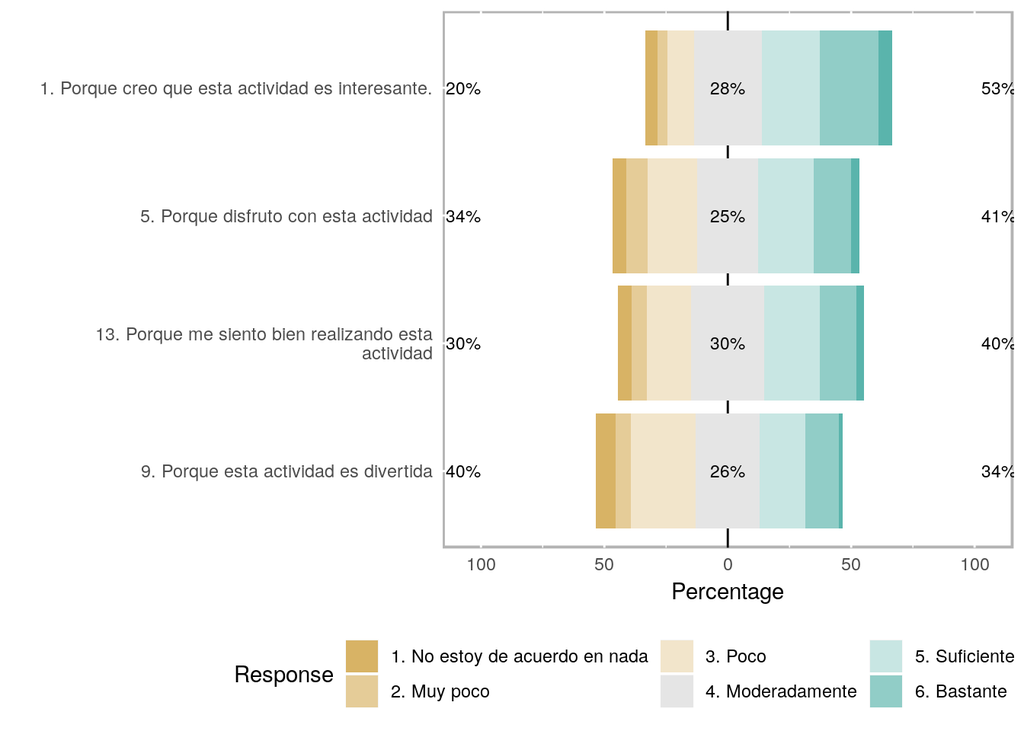

```r
# Motivación intrinseca ===================
lik.emsi.mintrinseca <- likert::likert(df.itemak.emsi[, mintrinseca])
# summary(lik.emsi.mintrinseca)
# str(lik.emsi.mintrinseca)
plot(lik.emsi.mintrinseca)
```

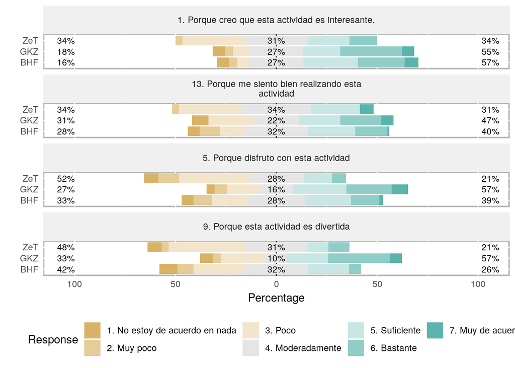

```r
# Fakultadeka
lik.emsi.mintrinseca.faku <- likert::likert(df.itemak.emsi[, mintrinseca], grouping = df.emsi$Faku)
# summary(lik.emsi.mintrinseca.faku)
# str(lik.emsi.mintrinseca.faku)
plot(lik.emsi.mintrinseca.faku)
```

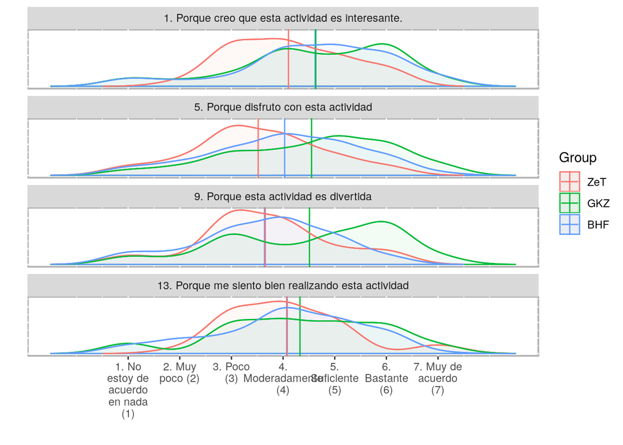

```r
plot(lik.emsi.mintrinseca.faku, type = 'density')
```

### Regulacion identificada

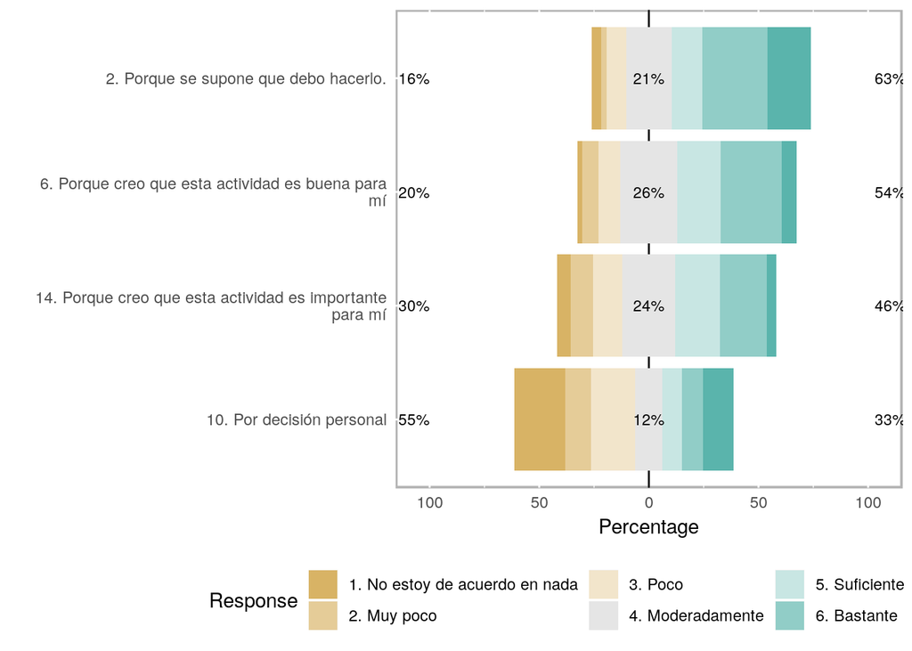

```r
# Regulacion identificada ==================
lik.emsi.mregulacionidentificada <- likert::likert(df.itemak.emsi[, mregulacionidentificada])
# summary(lik.emsi.mregulacionidentificada)
# str(lik.emsi.mregulacionidentificada)
plot(lik.emsi.mregulacionidentificada)
```

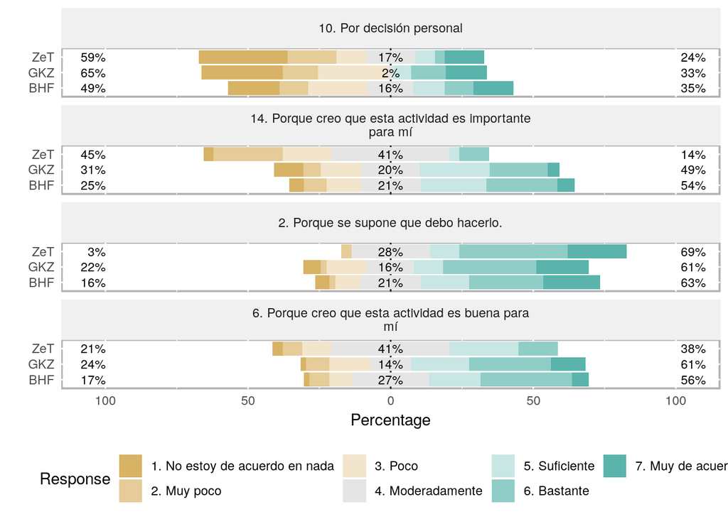

```r
# Fakultadeka
lik.emsi.mregulacionidentificada.faku <- likert::likert(df.itemak.emsi[, mregulacionidentificada], grouping = df.emsi$Faku)
# summary(lik.emsi.mregulacionidentificada.faku)
# str(lik.emsi.mregulacionidentificada.faku)
plot(lik.emsi.mregulacionidentificada.faku)
```

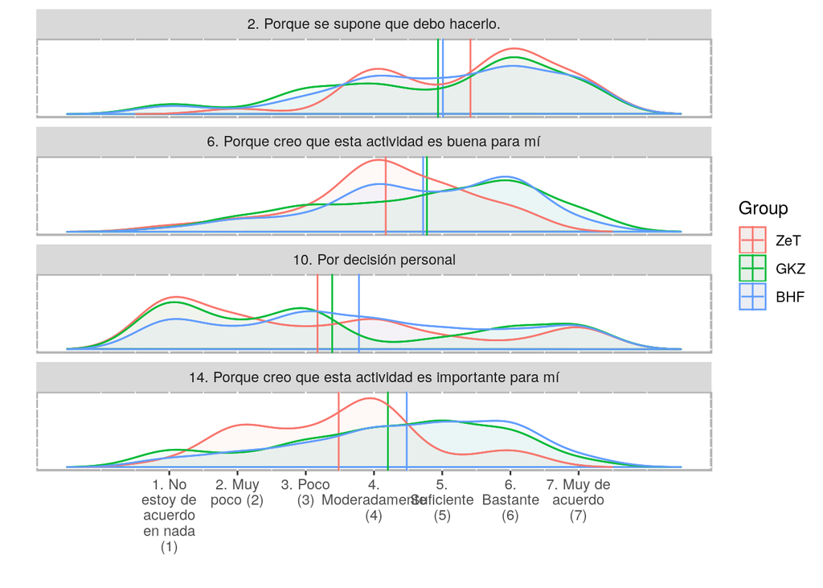

```r
plot(lik.emsi.mregulacionidentificada.faku, type = 'density')
```

### Regulación externa

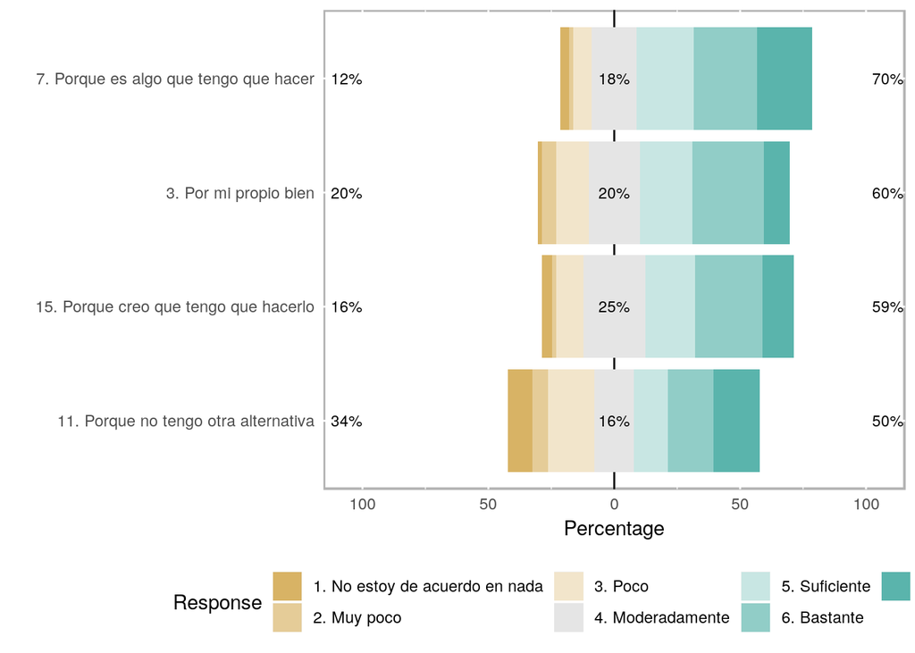

```r
# Regulación externa =======================
lik.emsi.mregulacionexterna <- likert::likert(df.itemak.emsi[, mregulacionexterna])
# summary(lik.emsi.mregulacionexterna)
# str(lik.emsi.mregulacionexterna)
plot(lik.emsi.mregulacionexterna)
```

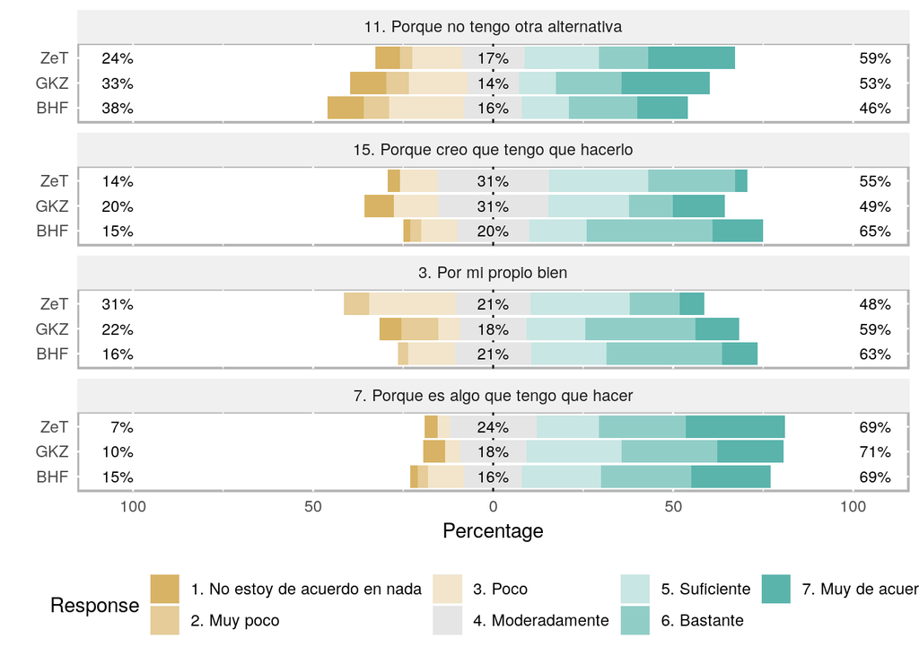

```r
# Fakultadeka
lik.emsi.mregulacionexterna.faku <- likert::likert(df.itemak.emsi[, mregulacionexterna], grouping = df.emsi$Faku)
# summary(lik.emsi.mregulacionexterna.faku)
# str(lik.emsi.mregulacionexterna.faku)
plot(lik.emsi.mregulacionexterna.faku)
```

#### Palta ixan dana

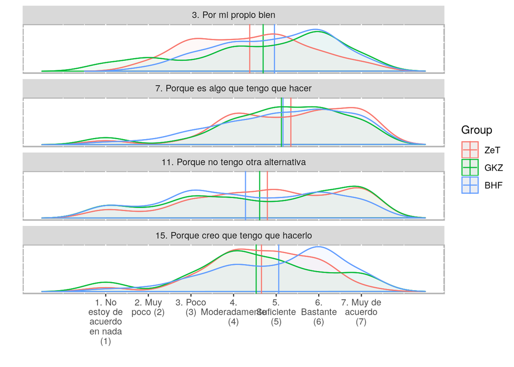

```r
plot(lik.emsi.mregulacionexterna.faku, type = 'density')
```

### Amotibazioa

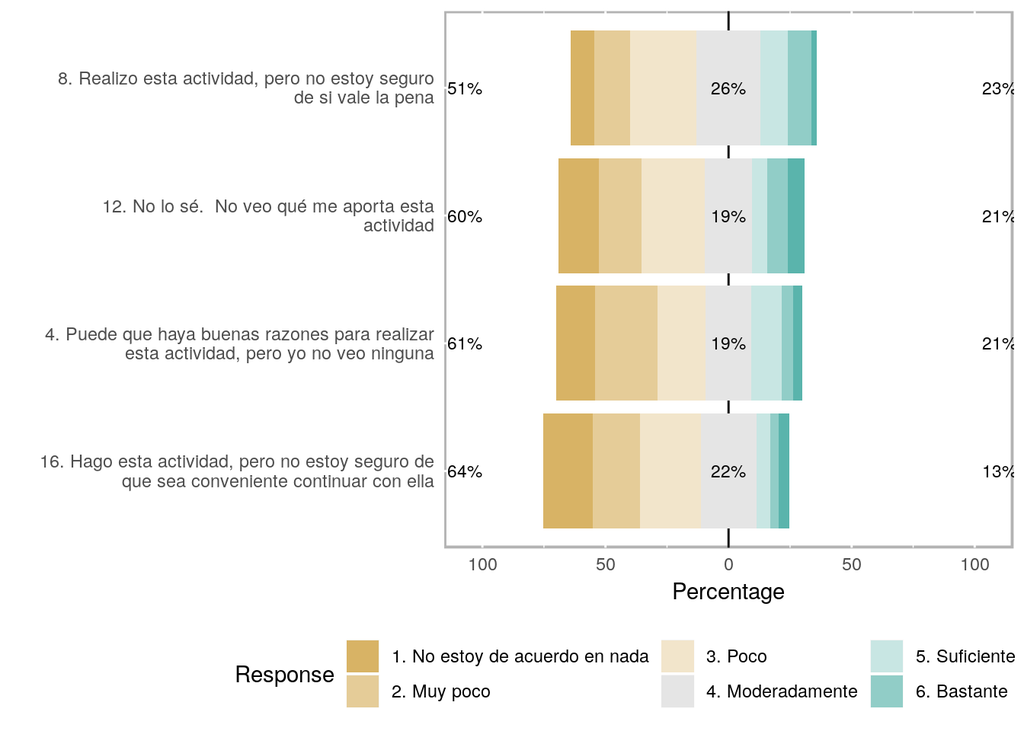

```r
# Amotibazioa ===============================
lik.emsi.mamotivacion <- likert::likert(df.itemak.emsi[, mamotivacion])
# summary(lik.emsi.mamotivacion)
# str(lik.emsi.mamotivacion)
plot(lik.emsi.mamotivacion)
```

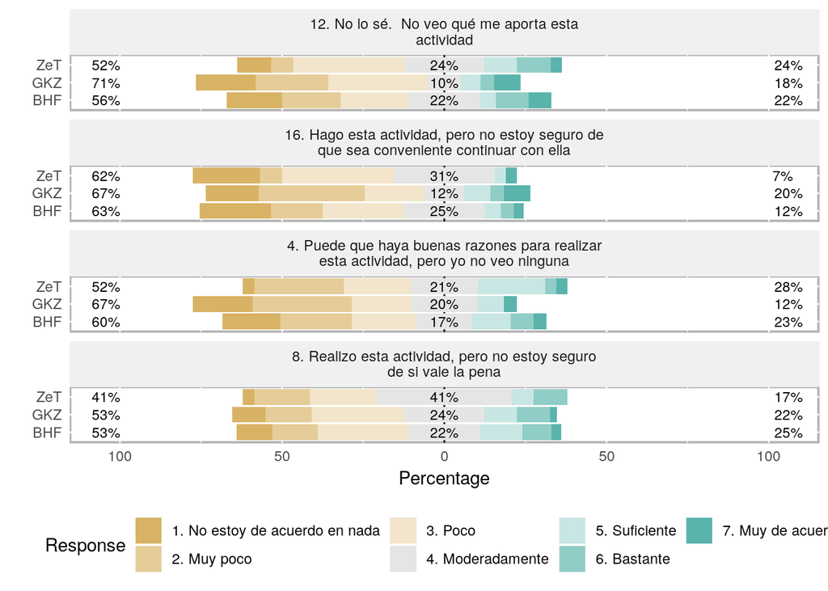

```r
# Fakultadeka
lik.emsi.mamotivacion.faku <- likert::likert(df.itemak.emsi[, mamotivacion], grouping = df.emsi$Faku)
# summary(lik.emsi.mamotivacion.faku)
# str(lik.emsi.mamotivacion.faku)
plot(lik.emsi.mamotivacion.faku)
```

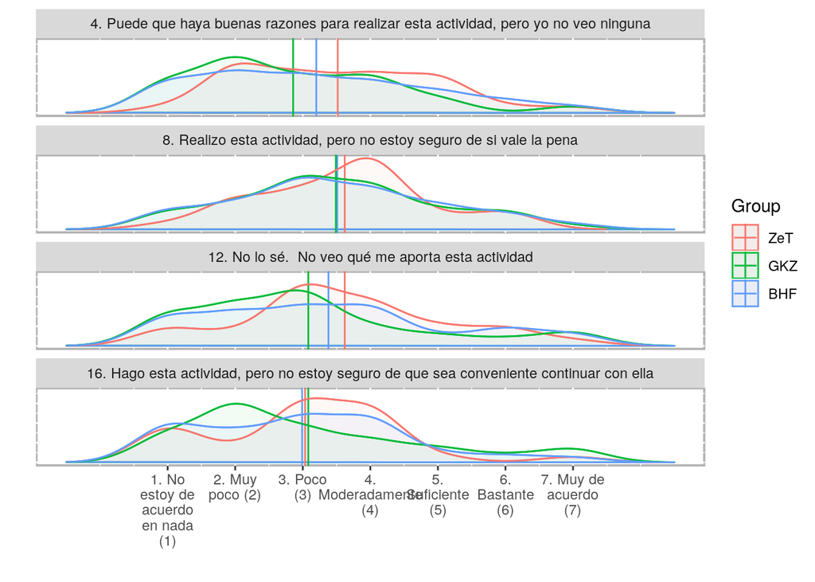

```r
plot(lik.emsi.mamotivacion.faku, type = "density")
```

## Gehitxuago esan liteke bide honetatik…

Efektuaren tamaina (aldia handia, txikia ala ertaina dan, zeozelan azalduta).

Hori egin behar izatera hurrengo horreei segidu bihar neukioe, baina ez bada behar, hoba. Denporaz estu nabil-eta ;-)

Alde esanguratsua aurkituta, efektuaren tamaina (ES) ere neurtu behar da. Horretarako `coin` paketeko `wilcox_test` erabili behar da *Z* balioa atarateko. Gero: `tamanyo_efecto <- 1.845/sqrt(n1 + n2)` `tamanyo_efecto`.

Neurriak:

- `0.1 =` txikia
- `0.3 =` ertaina
- `> 0.5` handia
[^1]: Numeruetakuk ez dabela mundu aitzen